# Question

Match each plot with its function. Different sources define `arccot` with different ranges. I’ve followed the `arccot` defined by Desmos and [wikipedia](https://en.wikipedia.org/wiki/Inverse_trigonometric_functions#Relationships_among_the_inverse_trigonometric_functions), with a range of $\left[0,\pi\right]$, not $\left[\frac{-\pi}{2},\,\frac{\pi}{2}\right]$. This choice gives a continuous function, but means that when $m<0$, $\arctan(\frac{1}{m})\ne \mathrm{arccot}(m)$. The other possible definition (not used here) is seen on [Wolfram Alpha](https://www.wolframalpha.com/input/?i=arccot+x).

## Plot 1

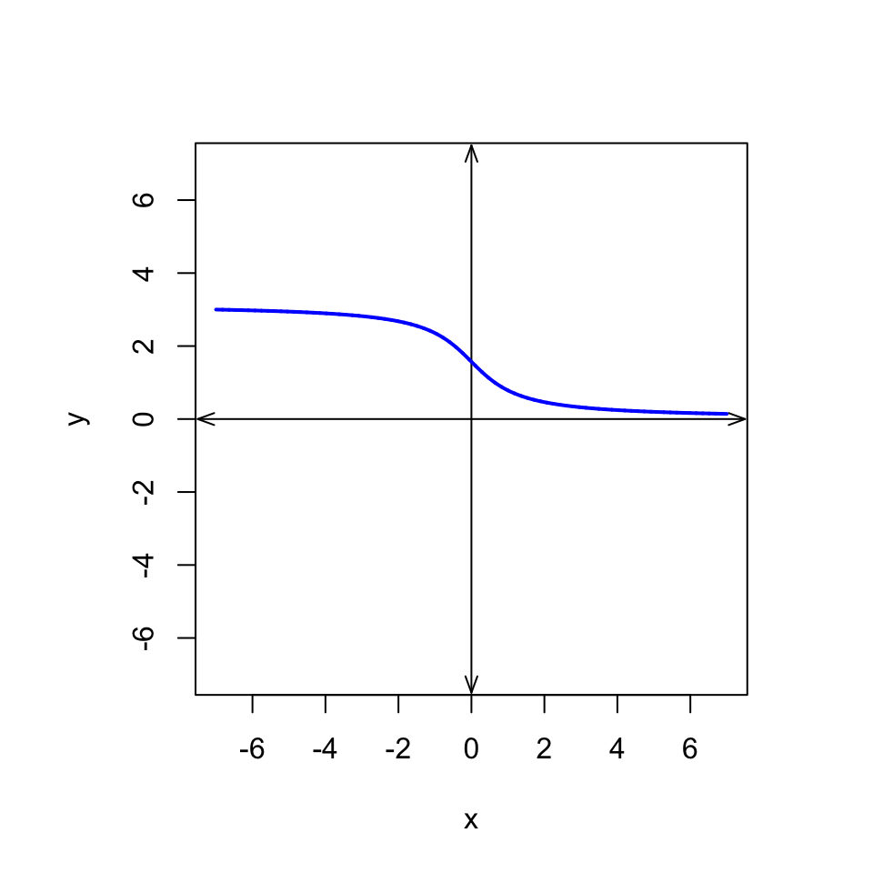

## Plot 2

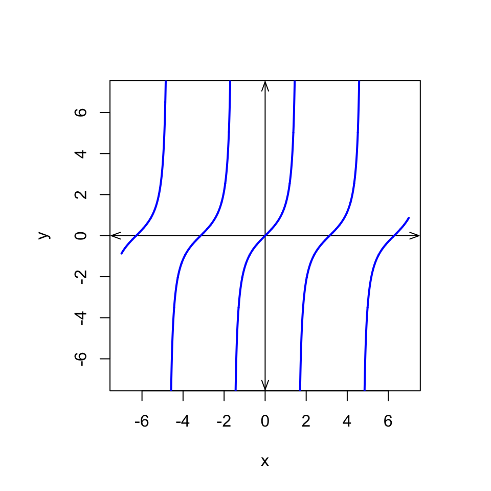

## Plot 3

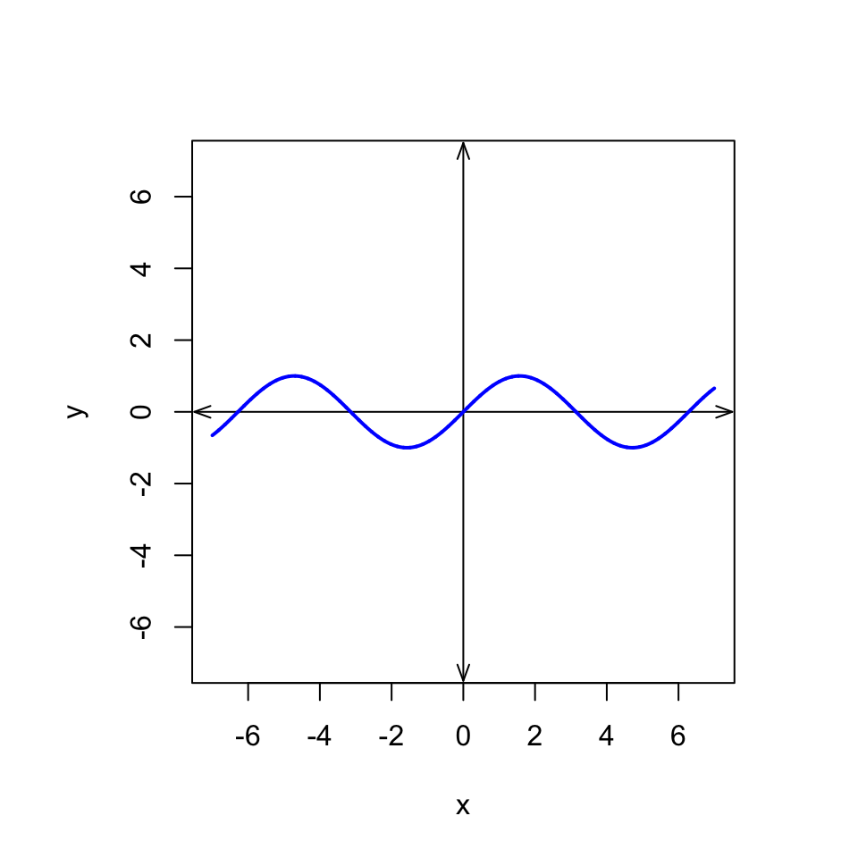

## Plot 4

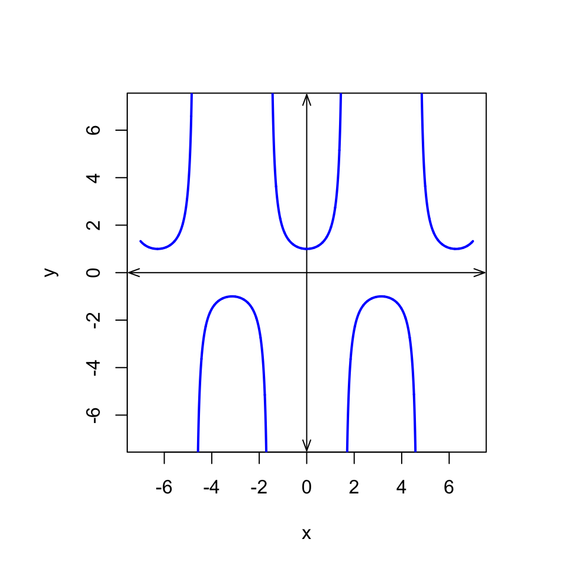

## Plot 5

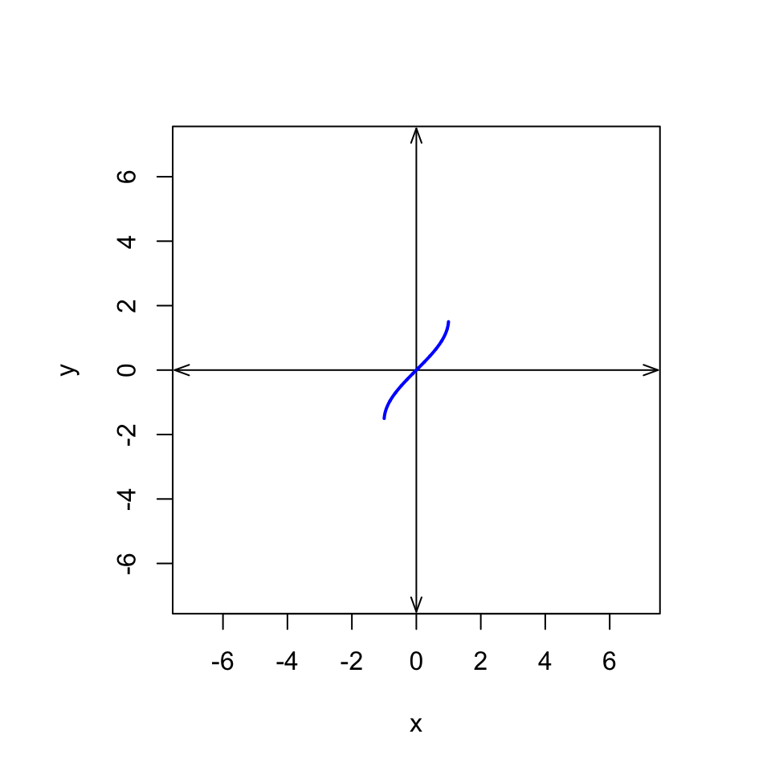

## Plot 6

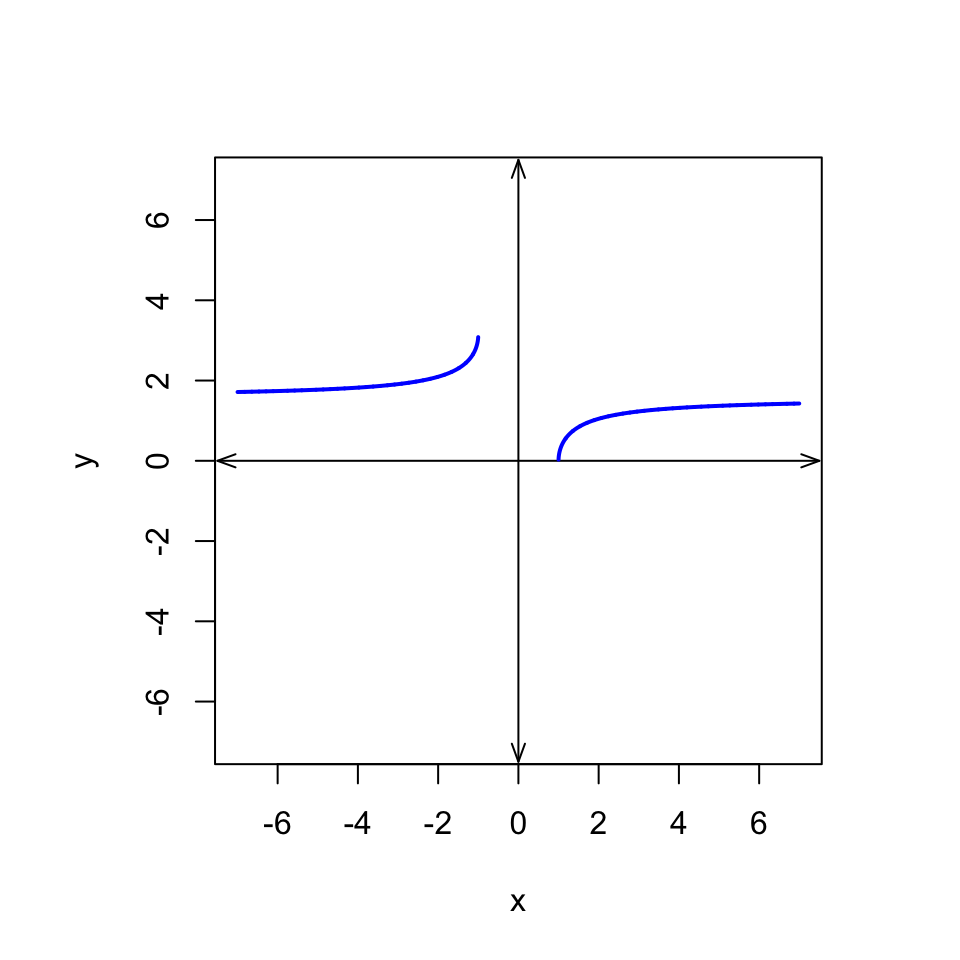

## Plot 7

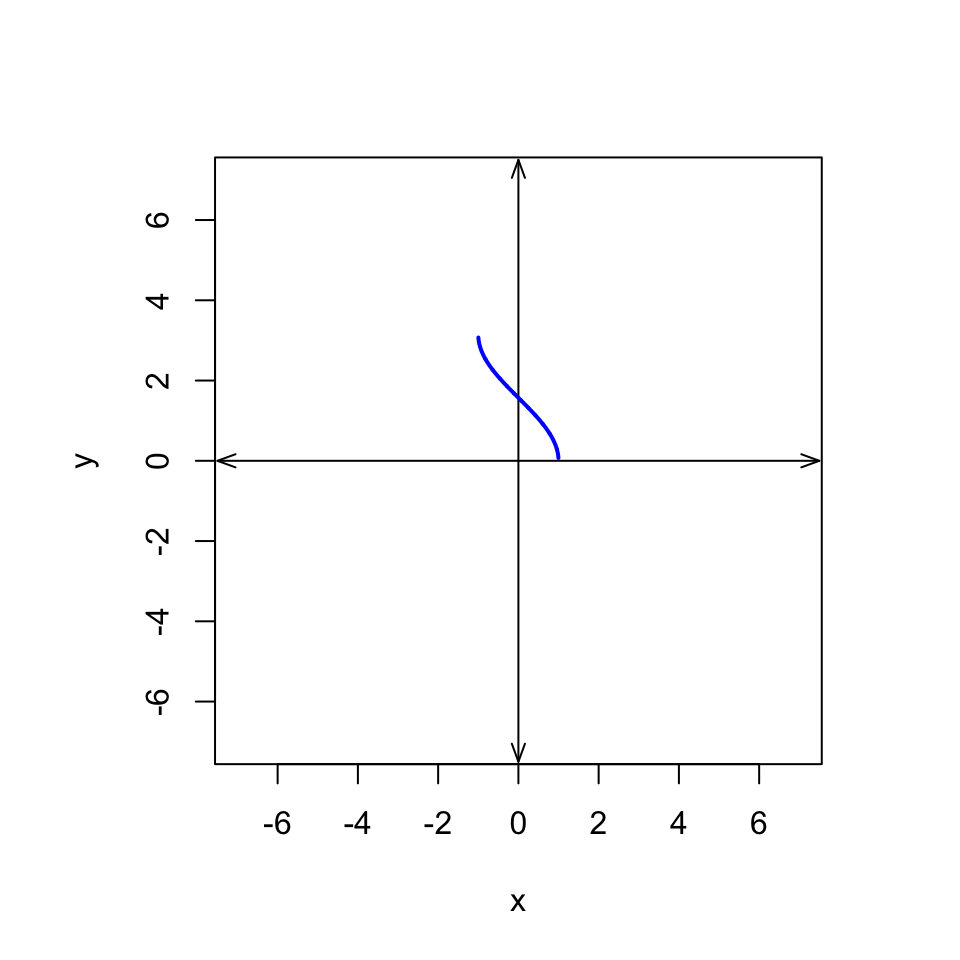

## Plot 8

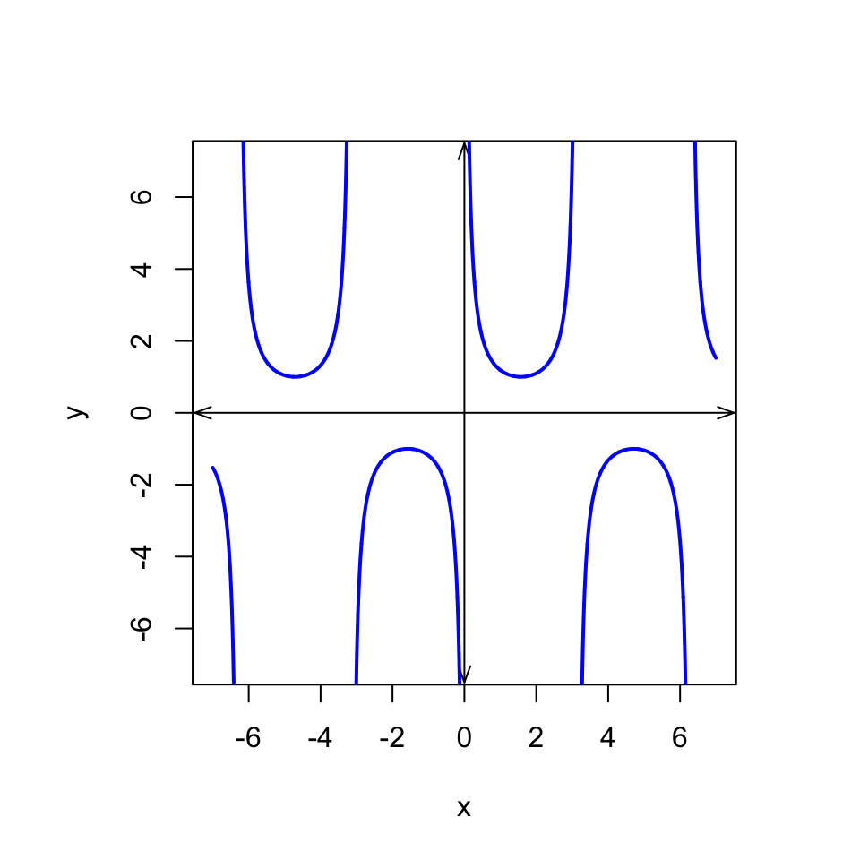

## Plot 9

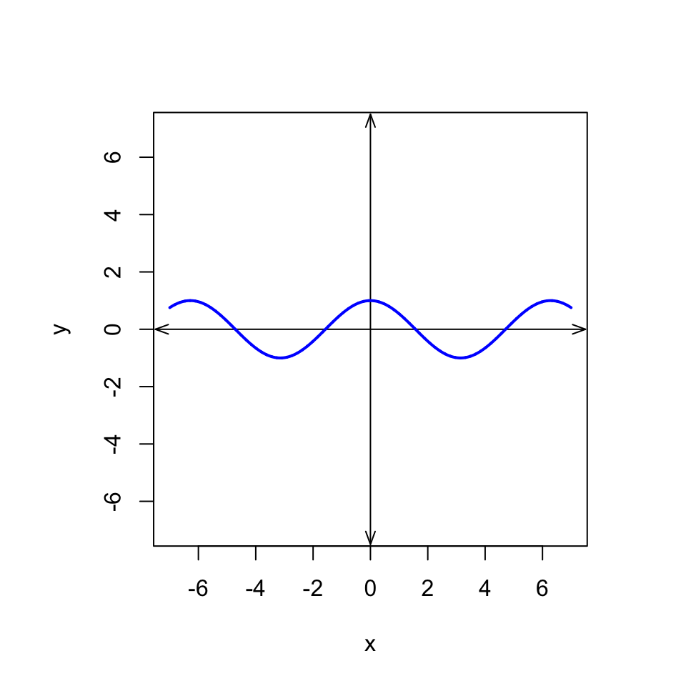

## Plot 10

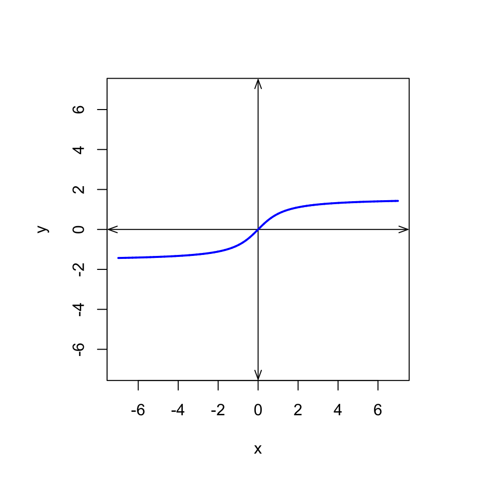

## Plot 11

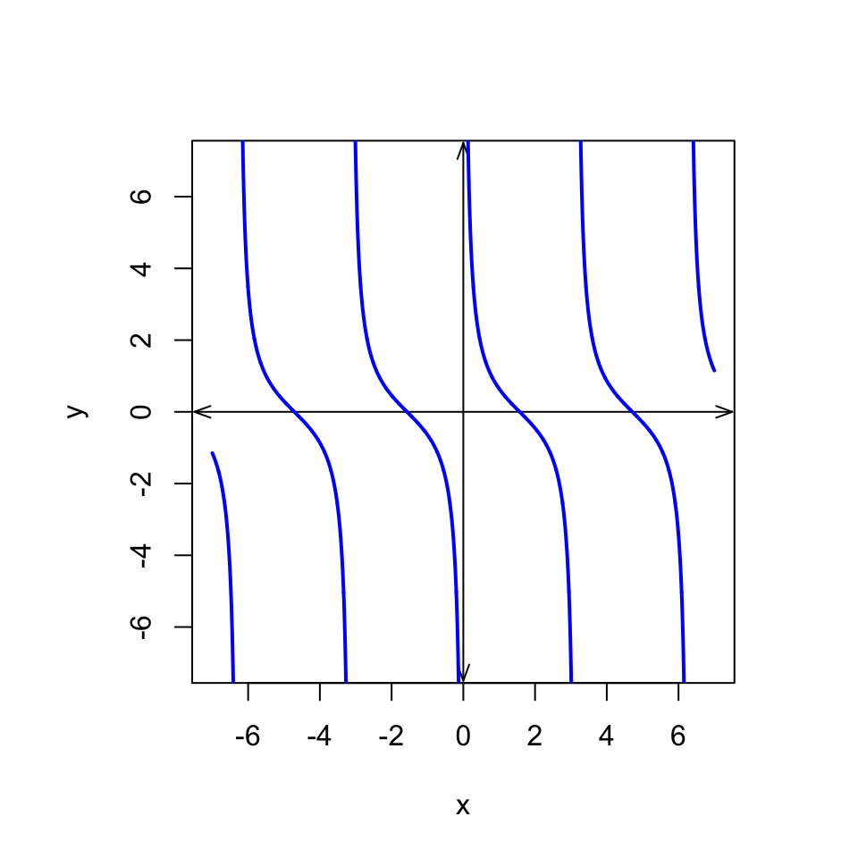

## Plot 12

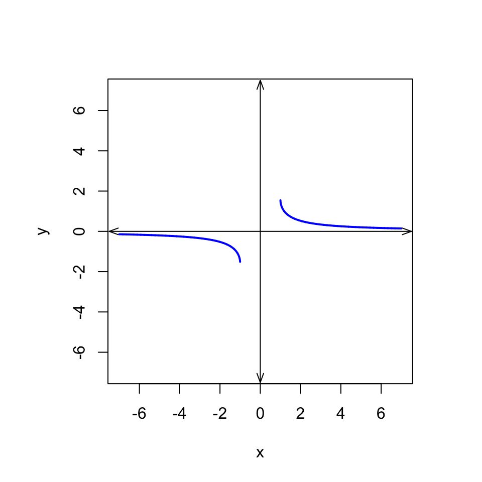

## Answerlist

- y = sin(x)
- y = cos(x)
- y = tan(x)
- y = csc(x)
- y = sec(x)
- y = cot(x)
- y = arcsin(x)
- y = arccos(x)
- y = arctan(x)
- y = arccsc(x)
- y = arcsec(x)
- y = arccot(x)
- y = sin(x)
- y = cos(x)
- y = tan(x)
- y = csc(x)
- y = sec(x)
- y = cot(x)
- y = arcsin(x)
- y = arccos(x)
- y = arctan(x)
- y = arccsc(x)
- y = arcsec(x)
- y = arccot(x)
- y = sin(x)
- y = cos(x)
- y = tan(x)
- y = csc(x)
- y = sec(x)
- y = cot(x)
- y = arcsin(x)
- y = arccos(x)
- y = arctan(x)
- y = arccsc(x)
- y = arcsec(x)
- y = arccot(x)
- y = sin(x)
- y = cos(x)
- y = tan(x)
- y = csc(x)
- y = sec(x)
- y = cot(x)
- y = arcsin(x)
- y = arccos(x)
- y = arctan(x)
- y = arccsc(x)
- y = arcsec(x)
- y = arccot(x)
- y = sin(x)
- y = cos(x)
- y = tan(x)
- y = csc(x)
- y = sec(x)
- y = cot(x)
- y = arcsin(x)
- y = arccos(x)
- y = arctan(x)
- y = arccsc(x)
- y = arcsec(x)
- y = arccot(x)
- y = sin(x)
- y = cos(x)
- y = tan(x)
- y = csc(x)
- y = sec(x)
- y = cot(x)
- y = arcsin(x)
- y = arccos(x)
- y = arctan(x)
- y = arccsc(x)
- y = arcsec(x)
- y = arccot(x)
- y = sin(x)
- y = cos(x)
- y = tan(x)
- y = csc(x)
- y = sec(x)
- y = cot(x)
- y = arcsin(x)
- y = arccos(x)
- y = arctan(x)
- y = arccsc(x)
- y = arcsec(x)
- y = arccot(x)
- y = sin(x)
- y = cos(x)
- y = tan(x)
- y = csc(x)
- y = sec(x)
- y = cot(x)
- y = arcsin(x)
- y = arccos(x)
- y = arctan(x)
- y = arccsc(x)
- y = arcsec(x)
- y = arccot(x)
- y = sin(x)
- y = cos(x)
- y = tan(x)
- y = csc(x)
- y = sec(x)
- y = cot(x)
- y = arcsin(x)
- y = arccos(x)
- y = arctan(x)
- y = arccsc(x)
- y = arcsec(x)
- y = arccot(x)
- y = sin(x)
- y = cos(x)
- y = tan(x)
- y = csc(x)
- y = sec(x)
- y = cot(x)
- y = arcsin(x)
- y = arccos(x)
- y = arctan(x)
- y = arccsc(x)
- y = arcsec(x)
- y = arccot(x)
- y = sin(x)
- y = cos(x)
- y = tan(x)
- y = csc(x)
- y = sec(x)
- y = cot(x)
- y = arcsin(x)
- y = arccos(x)
- y = arctan(x)
- y = arccsc(x)
- y = arcsec(x)
- y = arccot(x)
- y = sin(x)
- y = cos(x)
- y = tan(x)
- y = csc(x)
- y = sec(x)
- y = cot(x)
- y = arcsin(x)
- y = arccos(x)
- y = arctan(x)
- y = arccsc(x)
- y = arcsec(x)
- y = arccot(x)

# Solution

I’d recommend using a graphing utility, like [Desmos](https://www.desmos.com/calculator).

# Meta-information

extype: cloze exclozetype: schoice|schoice|schoice|schoice|schoice|schoice|schoice|schoice|schoice|schoice|schoice|schoice exsolution: 000000000001|001000000000|100000000000|000010000000|000000100000|000000000010|000000010000|000100000000|010000000000|000000001000|000001000000|000000000100 exname: identify_functions